# Roteiro para Monografia Final

Bio 312

Gabriel Marroig

October 20, 2016

Existem 5 espécies deste roedores alocadas ao gênero Dentus. Você têm medidas corporais tomadas com precisão de 0.01 mm no úmero (coluna 1), ulna (coluna 2), tíbia (coluna 3) e fêmur (coluna 4) para as 5 espécies. Além destes dados, existem na literatura alguns aspectos ecológicos efisiológicos das espécies.

- A espécie E apresenta um desenvolvimento desacelerado em relação às demais espécies do grupo.
- A espécie C é a única do grupo que vive em tocas, possuindo um hábito escavador.
- Já a espécie B tem a particularidade de viver em ambientes desérticos e apresentar uma locomoção diferenciada (bipedal) em relação às demais espécies, que são quadrúpudes.
- A espécie D tem o corpo bastante alongado e bastante variação de tamanho, sugerindo uma alocação de energia em crescimento bastante pronunciada.
- Finalmente, a espécie A apresenta um padrão de integração similar a do ancestral do grupo.

De posse destas medidas e das informações extraídas da literatura, o trabalho consiste em colocar no papel tudo que você aprendeu nas últimas aulas, analisando estes dados e interpretando os resultados. Em particular quero que os seguintes pontos sejam abordados:

1. Calcule a média, o desvio padrão e o coeficiente de variação para cada medida e cada espécie e compare caracterizando cada espécie.
2. Calcule as estimativas dos valores médios para os ancestrais usando a filogenia abaixo com comprimentos de ramo dados pela escala acima da filogenia. Calcule as diferenças médias entre as espécies (oito vetores $\Delta z$ ao longo dos ramos da filogenia). Calcule a norma dos vetores $\Delta z$ (ou seja, o comprimento desses vetores).

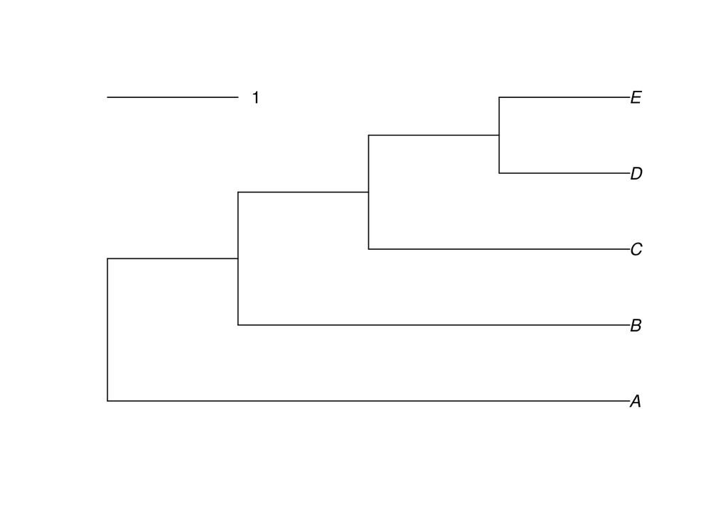

3. Compare a estrutura de variação e covariação entre os 4 caracteres nas 5 espécies. Discuta as semelhanças e diferenças entre as espécies no relacionamento destas medidas tanto em relação a padrões (correlações positivas ou negativas) como a magnitudes de associação entre os caracteres.
4. Compare estas diferenças ($\Delta z$) com o primeiro (PC1) e segundo (PC2) componente principal de cada espécie, por meio de correlação de vetores.
5. Descreva e compare as linhas de menor resistência evolutiva em cada uma destas espécies (correlação dos PC1s e dos PC2s entre as espécies).
6. Calcule as matrizes ponderadas para cada nó na filogenia. Compare os $\Delta z$ do item 2 com os PC1 e PC2 de cada matriz ancestral (nó) do qual aquele ramo da filogenia têm origem.
7. Discuta as diferenças entre as espécies a luz do conceito de linhas de menor resistência evolutiva.
8. Reconstrua os gradientes de seleção para cada ramo da filogenia.
9. Escreva um ensaio no qual todas as informações acima são organizadas em forma de tabelas e figuras e discutidas propriamente em termos de tudo aquilo que vocês aprenderam nas aulas e das associações passíveis de serem feitas com as informações ecológicas e fisiológicas.